# Adding levels of randomness

# Stochastic minute

## Exponential, and Gamma

If $T \sim \Exp(\text{rate}=\lambda)$, then

$$\begin{aligned}
\P\{ T \in dt \} = \lambda e^{-\lambda t} dt .
\end{aligned}$$

1. $T$ can be any nonnegative real number.
2. $T$ is *memoryless*:
   $$\begin{aligned}
   \P\{ T > x + y \given T > x \} = \P\{ T > y \} .
   \end{aligned}$$
3. A machine produces $n$ widgets per second; each widget has probability $\lambda/n$ of being broken. The time until the first broken widget appears (in seconds) is approximately $\sim \Exp(\lambda)$.

If $S \sim \Gam(\text{shape}=\alpha, \text{rate}=\lambda)$, then

1. If $T_1, \ldots, T_k$ are independent $\Exp(\lambda)$, then $S = T_1 + \cdots + T_k$ is $\Gam(k, \lambda)$.
2. A machine produces $n$ widgets per second; each widget has probability $\lambda/n$ of being broken. The time until the $k^\text{th}$ broken widget appears (in seconds) is approximately $\sim \Gam(k, \lambda)$.

# “Hierarchical Coins” with Stan

## Baseball

We have a dataset of batting averages of baseball players, having

1. name
2. position
3. number of “at bats”
4. number of hits

```r
batting <- read.csv("../demos/BattingAverage.csv", header=TRUE)
head(batting)
```

```
##          Player     PriPos Hits AtBats PlayerNumber PriPosNumber
## 1 Fernando Abad    Pitcher    1      7            1            1
## 2   Bobby Abreu Left Field   53    219            2            7
## 3    Tony Abreu   2nd Base   18     70            3            4
## 4 Dustin Ackley   2nd Base  137    607            4            4
## 5    Matt Adams   1st Base   21     86            5            3
## 6 Nathan Adcock    Pitcher    0      1            6            1
```

The *overall* batting average of the 948 players is 0.2546597.

Here is the average by position.

```r
batting %>% group_by(PriPos) %>%
    summarise(num=n(), BatAvg=sum(Hits)/sum(AtBats)) %>%
    select(PriPos, num, BatAvg)
```

```
## # A tibble: 9 x 3
##   PriPos         num BatAvg
##   <fctr>       <int>  <dbl>
## 1 1st Base        81  0.259
## 2 2nd Base        72  0.256
## 3 3rd Base        75  0.265
## 4 Catcher        103  0.247
## 5 Center Field    67  0.264
## 6 Left Field     103  0.259
## 7 Pitcher        324  0.129
## 8 Right Field     60  0.264
## 9 Shortstop       63  0.255
```

## Questions?

1. What’s the overall batting average?
2. Do some positions tend to be better batters?
3. How much variation is there?

## Everyone is the same

```r
first_model <- "
data {
    int N;
    int hits[N];
    int at_bats[N];
}
parameters {
    real<lower=0, upper=1> theta;
}
model {
    hits ~ binomial(at_bats, theta);
    theta ~ beta(1, 1);
} "
first_fit <- stan(model_code=first_model, chains=3, iter=1000,
                  data=list(N=nrow(batting),
                            hits=batting$Hits,
                            at_bats=batting$AtBats))
```

[output not shown]

[output cut: 16 more lines]

[output not shown]

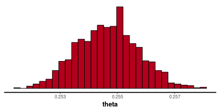

```r
stan_hist(first_fit)
```

```r
pos_model <- "
data {
    int N;
    int hits[N];
    int at_bats[N];
    int npos; // number of positions
    int position[N];
}
parameters {
    real<lower=0, upper=1> theta[npos];
}
model {
    real theta_vec[N];
    for (k in 1:N) {
        theta_vec[k] = theta[position[k]];
    }
    hits ~ binomial(at_bats, theta_vec);
    theta ~ beta(1, 1);
} "
pos_fit <- stan(model_code=pos_model, chains=3, iter=1000,
                  data=list(N=nrow(batting),
                            hits=batting$Hits,
                            at_bats=batting$AtBats,
                            npos=nlevels(batting$PriPos),
                            position=as.numeric(batting$PriPos)))
```

[output not shown]

[output cut: 16 more lines]

[output not shown]

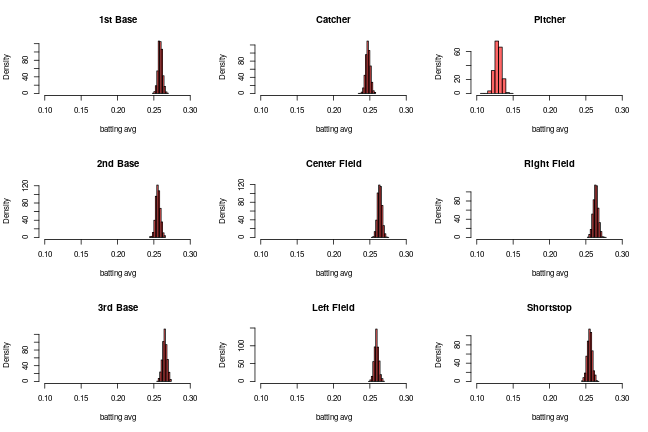

```r
theta_samples <- extract(pos_fit)$theta
layout(matrix(1:9, nrow=3))
for (k in 1:ncol(theta_samples)) {
    hist(theta_samples[,k], main=levels(batting$PriPos)[k], xlim=c(0.1, 0.3),
         col=adjustcolor('red',0.6), xlab='batting avg', freq=FALSE)
}
```

## Your turn :

Every individual different:

$$\begin{aligned}
Z_i &\sim \Binom(N_i, \theta_i) \\
\theta_i &\sim \Beta(\omega_{p_i}, \kappa_{p_i}) \\
\omega_p &\sim \Beta(1, 1) \\
\kappa_p &\sim \Gam(0.1, 0.1) .
\end{aligned}$$

Variable types in Stan:

```
int x;       // an integer
int y[10];   // ten integers
real z;      // a number
real z[2,5]; // a 2x5 array of numbers

vector u[10];      // length 10 vector
matrix v[10,10];   // 10x10 matrix
vector[10] w[10];  // ten length 10 vectors
```

- don’t forget the `;`
- make sure R types match
- read the error messages

```r
pos_model <- "
data {
    int N;   // number of players
    int hits[N];
    int at_bats[N];
    int npos; // number of positions
    int position[N];
}
parameters {
    real<lower=0, upper=1> theta[N];
    real<lower=0, upper=1> omega[npos];
    real<lower=0> kappa[npos];
}
model {
    real alpha[N];
    real beta[N];
    for (i in 1:N) {
        alpha[i] = omega[position[i]] * kappa[position[i]];
        beta[i] = (1 - omega[position[i]]) * kappa[position[i]];
    }
    hits ~ binomial(at_bats, theta);
    for (i in 1:N) {
        theta[i] ~ beta(alpha[i], beta[i]);
    }
    omega ~ beta(1,1);
    kappa ~ gamma(0.1,0.1);
} "
```

```r
pos_fit <- stan(model_code=pos_model, chains=3, iter=1000,
                  data=list(N=nrow(batting),
                            hits=batting$Hits,
                            at_bats=batting$AtBats,
                            npos=nlevels(batting$PriPos),
                            position=as.numeric(batting$PriPos)))
```

## What questions can we ask?

(discussion / see Kruschke Ch. 9)

# Sharing power // Shrinkage

## Example

Suppose that I have a large pot of coins that are all similar to each other. I flip each one ten times, and record the number of Heads. What is *each coin’s* probability of Heads?

- Treated *separately*, we would be very uncertain about each coin.
- Together, they should tell us very accurately what are *likely* values of $\theta$.
- This information can improve the estimate of each separate $\theta$.

How does shrinkage affect the baseball inference?